# Blog with RStudio, R, RMarkdown, Jekyll and Github.(from Andy South)

Andy South

In the first post of this new blog I’ll outline how I’ve set the blog up.

- writing posts in `Rmarkdown`
- converting posts to markdown from R
- push to Github where Jekyll renders the markdown
- organising all as an RStudio project

## What I wanted

I wanted to be able to write about R related things without having to copy and paste code, figures or files. I had used [Rmarkdown](http://rmarkdown.rstudio.com/) and [knitr](http://yihui.name/knitr/) before so wanted to use them. I have a wordpress site elsewhere that someone helped me set up a couple of years ago with a blog that I’ve never used. Initially I tried seeing if I could create posts using `RMarkdown` and put them into that wordpress blog. A brief search revealed that was not straightforward and that Jekyll was the way to go.

## What I’ve got

Now I have this blog set up so that I can write all of the posts (including this one) in RMarkdown (`.Rmd`) and run an R function to convert them to markdown (`.md`). The blog is hosted for free on [Github](https://github.com/) (you get one free personal site). The site is created using [Jekyll](http://jekyllrb.com/) on Github, so I didn’t need to install Jekyll or Ruby. I simply edit files locally, then commit and push to Github. I manage the site as an RStudio project, enabling me to edit text, keep track of files and interact with Git all from one interface.

## How I got here (steps)

### creating Jekyll site on Github

I used Barry Clarks amazing [Jekyll-Now repository](https://github.com/barryclark/jekyll-now) which you can fork directly from Github and start editing to customize. He gives excellent instructions. What attarcted me to it was that it takes a matter of minutes to set up initially and if you decide you don’t like it you can just delete.

Thanks to Jan Gorecki whose answer on [stackoverflow](http://stackoverflow.com/a/26703757/1718356) pointed me in this direction and I’ve copied some extra features like the Links and Index pages from his [site](https://github.com/jangorecki/jangorecki.github.io).

### enabling editing of the site from RStudio

I cloned the Github repository for my site using RStudio :

- File, New project, Version control, Clone git
- Repo URL : https://github.com/AndySouth/andysouth.github.io
- Project directory name : andysouth.github.io

### setting up so that I can write the posts in RMarkdown

This was the tricky bit for me. I followed inspiration from [Jason Bryer](http://jason.bryer.org/posts/2012-12-10/Markdown_Jekyll_R_for_Blogging.html) and [Jon Zelner](http://www.jonzelner.net/jekyll/knitr/r/2014/07/02/autogen-knitr/). I had to tweak them both, the relative paths of figures was my main stumbling block. This was partly because I’m running windows and I couldn’t run the shell scripts that they created. Instead I just run an R function [rmd2md](https://github.com/AndySouth/andysouth.github.io/blob/master/rmd2md.r) which is much the same as Jason’s with some edits to paths and jekyll rendering.

Jason’s function searches a folder that you specify for `.Rmd` files and then puts `.md` files into another folder. I set this up so that any plots are put into a third folder. Thus in the root of my site includes these 3 folders.

[output not shown]

This then means that any R plot is automatically generated, saved as a png and it’s address is written into the md document so that the plot is displayed in the blog. This is shown in a simple example below that queries the WHO API to get the number of cases of one of the forms of sleeping sickness in 2013.

```r
code <- "NTD_4"
year <- 2013
url <- paste0('http://apps.who.int/gho/athena/api/GHO/',code,'.csv?filter=COUNTRY:*;YEAR:',year)
#read query result into dataframe
dF <- read.csv(url,as.is=TRUE)
library(rworldmap)
sPDF <- joinCountryData2Map(dF, nameJoinColumn="COUNTRY", joinCode="ISO3")
```

```
## 24 codes from your data successfully matched countries in the map
## 0 codes from your data failed to match with a country code in the map
## 220 codes from the map weren't represented in your data
```

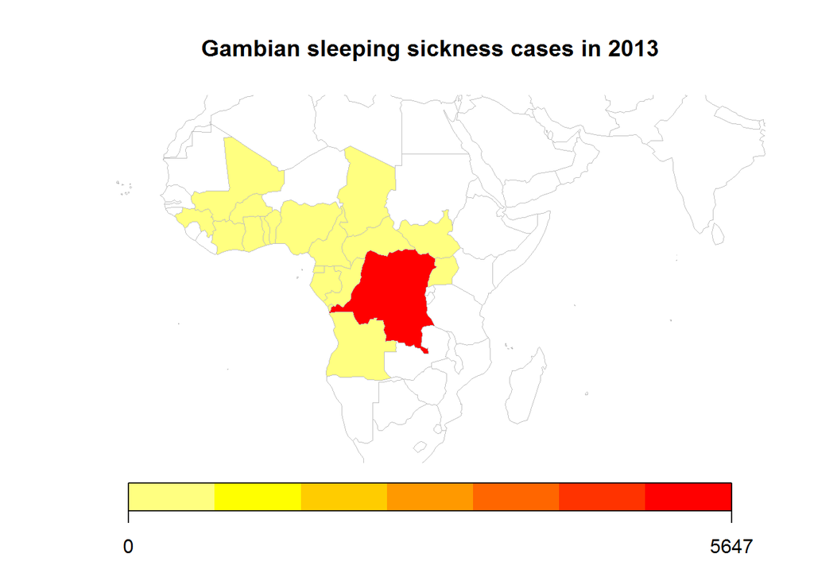

```r
mapCountryData(sPDF,nameColumnToPlot="Numeric",catMethod="fixedWidth",mapRegion="africa", mapTitle="Gambian sleeping sickness cases in 2013")
```

The code syntax highlighting and dark grey background for both code and R text outputs are what come as the default with Jekyll-Now. I’m a little unsure about them. They seem to be specified in _highlights.scss, perhaps I’ll look at modifying later.

If you’d like to look here is the [entire source code](https://github.com/AndySouth/andysouth.github.io/) for the blog and for this [individual page](https://github.com/AndySouth/andysouth.github.io/blob/master/_rmd/2014-12-10-blog-setup.Rmd).